# Grafički prostorni prikaz tlaka zraka u Republici Hrvatskoj

### Uvod

Projektni zadatak je izraditi R program koji će obrađivati podatke o tlaku zraka u Republici Hrvatskoj.  
Podaci se nalaze na web sjedištu Državnog Hidrometeorološkog zavoda na adresi: http://meteo.hr/naslovnica_aktpod.php?tab=aktpod  
Podatke je potrebno prikupiti, analizirati, transformirati i sa njima napraviti dvije prostorne interpolacije. Te dobiveni rezultat interpolacija grafički prikazati.  
Zadatak je, radi lakše izrade, podjeljen u više dijelova:

1. Prikupljanje podataka
2. Transfromacija podataka
3. Interpolacija metodom najblizih susjeda
4. Interpolacija metodom diobe prostora

### Import potrebnih knjižnica funkcija

```r
library(rvest)
library(stringr)
library(sf)
library(raster)
library(maps)
library(ggplot2)
library(ggvoronoi)
library(rworldmap)
library(dplyr)
require(viridis)
```

### Prikupljanje podataka

U ovome dijelu se dohvaća html kod stranice. HTML kod je spremljen u varijablu page. U page varijabli su sadržani izvorni podaci.  
Iz html koda, pomoću funkcije html_nodes() izdvajaju se sve tablice. Zatim se iz polja tablica uzima 3.tablica koja sadrži podatke mjerenja sa mjernih postaja.

```r
url = "http://meteo.hr/naslovnica_aktpod.php?tab=aktpod,tablica"

#dohvacanje html dokumenta
page = read_html(url)

#filtriranje tablica
tables = html_nodes(page, "table")

#citanje podataka iz 3. tablice (u njoj su podaci)
table = html_table(tables[3], trim = TRUE, convert = TRUE, dec = ".", fill = TRUE)
```

### Transformacija podataka

Nakon dohvata izvornih podataka, podatke je potrebno transformirati. Podaci se tranosformiraju u format koji će zadovoljavati njihovu buduću obradu.

Tablica se pretvara u dataframe objekt te se uzimaju samo stupci od interesa. Stupci od interesa su: Postaja i Tlak zraka.  
Podaci se čiste, briše se mjerenje na aerodromu, brišu se unosi za koje ne postoji mjerenje tlaka, uklanja se character “*” iz zapisa tlaka te se vrijednosti u stupcu tlaka pretvaraju u numerički tip podataka.

```r
#pretvaranje u data frame
dfOriginal = as.data.frame(table)

#uklanjanje svih stupaca osim imena mjesta i tlaka
dfmod = dfOriginal[,-c(2,3,4,5,7,8)]

#uklanjanje aerodroma
dfmod = dfmod[!grepl("-aero", dfmod[[1]], fixed = TRUE),]

#uklanjanje svih mjesta na kojima tlak nije izmjeren
dfmod = dfmod[!grepl("-", dfmod[[2]], fixed = TRUE),]

#uklanjanje zvjezdice iz podataka o tlaku
dfmod[[2]] = str_remove(dfmod[[2]], "\\*")

#pretvaranje tlakova u numericke podatke
dfmod[[2]] = as.numeric(dfmod[[2]])
```

Ručno je izrađena csv datoteka naziva locations.csv. Datoteka sadrži geografske koordinate svih mjernih postaja.  
Potrebno je svakoj mjernoj postaji dodijeliti odgovarajuće geografske koordinate.  
Deklariraju se polja za geografsku širinu i geografsku dužinu. Zatim se iterira kroz dataframe sa mjerenjima tlaka te se traže jednaki retci tablice mejerenja i tablice lokacija. Kada se pronađe jednaki unos, koordinate iz tablice lokacija se zapisuju u polja LAT i LNG.  
Na kraju se uklanjaju unosi za koje ne postoje odgovarajuće lokacije te se polja LAT i LNG dodaju kao nove kolone u dataframe sa mjerenjima tlaka.

```r
#ucitavanje koordinata
loc = read.csv('/Users/dino/Documents/Diplomski/Lokacije/Projekt/locations.csv', header = TRUE, encoding = "UTF-8")

LAT = c()
LNG = c()
REMOVEROWS = c()

#pridruzivanje koordinata mjestima u tablici mjerenja
for (i in 1:dim(dfmod)[1])
{
  idx = match(dfmod[i,1], loc[[1]])
  if (!is.na(idx))
  {
    LAT = c(LAT, loc[idx,2])
    LNG = c(LNG, loc[idx,3])
  }
  else
  {
    print(dfmod[i,1])
    REMOVEROWS = c(REMOVEROWS, i)
  }
}

#uklanjanje svih redova za koje nema odgovarajuca lokacija
if (!is.null(REMOVEROWS))
{
  dfmod2 = dfmod2[-REMOVEROWS,]
}
dfmod2 = cbind(dfmod, LAT, LNG)
```

### Interpolacija metodom najbližih susjeda

Sljedeći porgramski kod generira mrežu točaka predikcije. Za svaku točku predikcije se traži najbliža točka mejerenja. Nakon što su pronađene sve najbliže točke, točkama predikcije se dodjeljuje vrijednost tlaka na najbližoj mjernoj postaji. Na kraju se izrađuje karta hrvatske te se karta prikazuje zajedno sa interpoliranim vrijednostima.

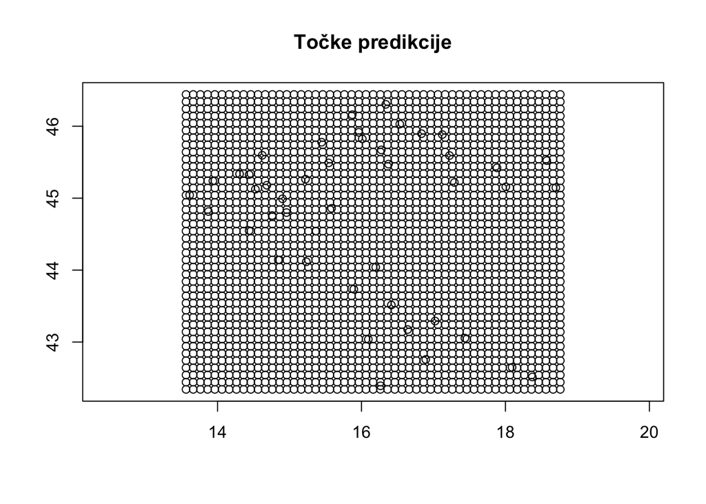

```r
#convert dataframe to simple collection
tlakSc =  st_as_sf(dfmod2, coords = c('LNG', 'LAT'), remove = F)

#Napravi prediction gird, tocke predikcije
nodes = st_make_grid(st_buffer(tlakSc$geometry, 0.1), cellsize = 0.1, what = "centers")
plot(nodes, axes = TRUE,  main = "Točke predikcije")
plot(tlakSc$geometry, add = TRUE, color="red")
```

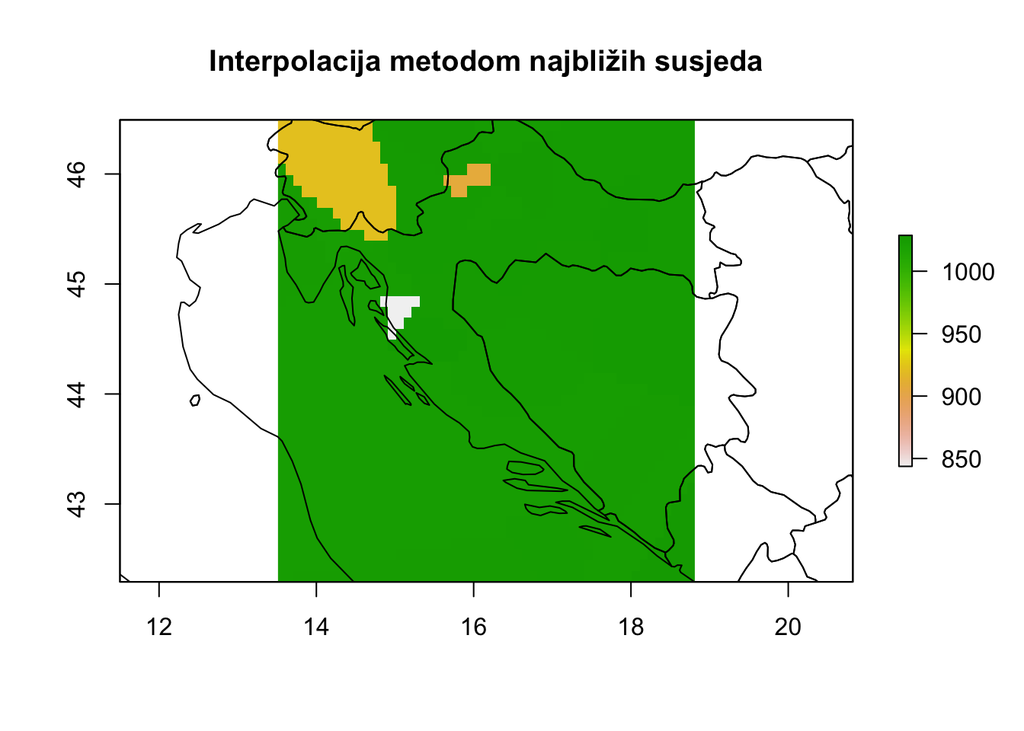

```r
nodes = as(nodes, "Spatial")
class(nodes)

#izracunaj udaljenost izmedu svake tocke mjerne i postje i tocke grida
#Stupci su mjerne postaje, retci su tocke predikcije
udaljenosti = pointDistance(nodes, as(tlakSc$geometry, "Spatial"), lonlat=TRUE)

#za svaku tocku predikcije pronadi najblizu mjernu postaju
#Pornade za svaki redak udaljenosti, index najblize postaje
najblize = apply(udaljenosti, 1, function(x) which(x == min(x)))

#Rename
colnames(tlakSc)[2] = "Tlak"

#Dodaj vrijednost tlaka svakoj tocki predikcije
tlakovi = tlakSc$Tlak[najblize]

#Napravi kopiju tocki predikcije
predikcija = nodes
#Napravi novi stupac sa vrijednostima tlaka
predikcija$tlak = tlakovi

gridded(predikcija) = TRUE

predikcija = raster(predikcija)
plot(predikcija, main = "Interpolacija metodom najbližih susjeda")
#create new map
newmap = getMap(resolution = "low")
plot(newmap, add=TRUE, xlim = c(13.48, 19.45), ylim = c(42.391, 46.555))
```

### Interpolacija metodom diobe prostora (teselacija)

Za postizanje interpolacije korsite se Voronoi-evi dijagrami. Voronoi-ev dijagram se sastoji od ćelija, gdje svaka ćelija sadrži točke koje su najbliže točki opažanje te ćelije.  
U programskom okruženju R za prikaz voronoi-evih ćelija koristi se funkcija geom_voronoi(). Zatim se kreira dataframe, naziva cro, sa koordinatama hrvatske. Zatim se prikazuje voronoi-ev dijagram zajedno sa kartom hrvatske.

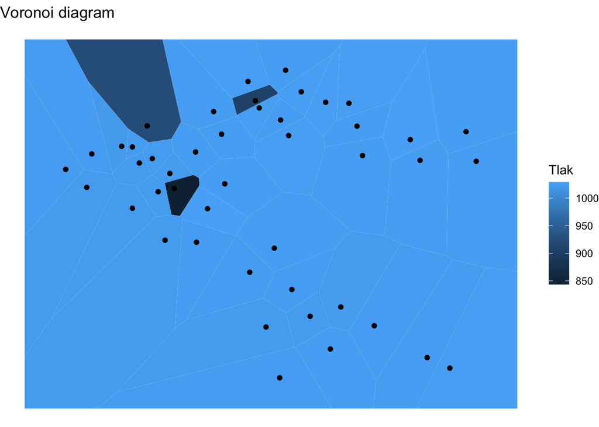

```r
voronoi = ggplot(tlakSc, aes(LNG, LAT, fill = Tlak)) + geom_voronoi() + geom_point() + ggtitle("Voronoi diagram")

theme_set(
  theme_void()
)
cro <- map_data("world", region =  "Croatia")
region.lab.data = cro %>%
  group_by(region) %>%
  summarise(long = mean(long), lat = mean(lat))

finalPlot = voronoi + geom_path(data = cro, aes(x = long, y = lat, fill = group)) + theme_void() + theme(legend.position = "none") + ggtitle("Interpolacija metodom diobe prostora")

plot(voronoi)
```

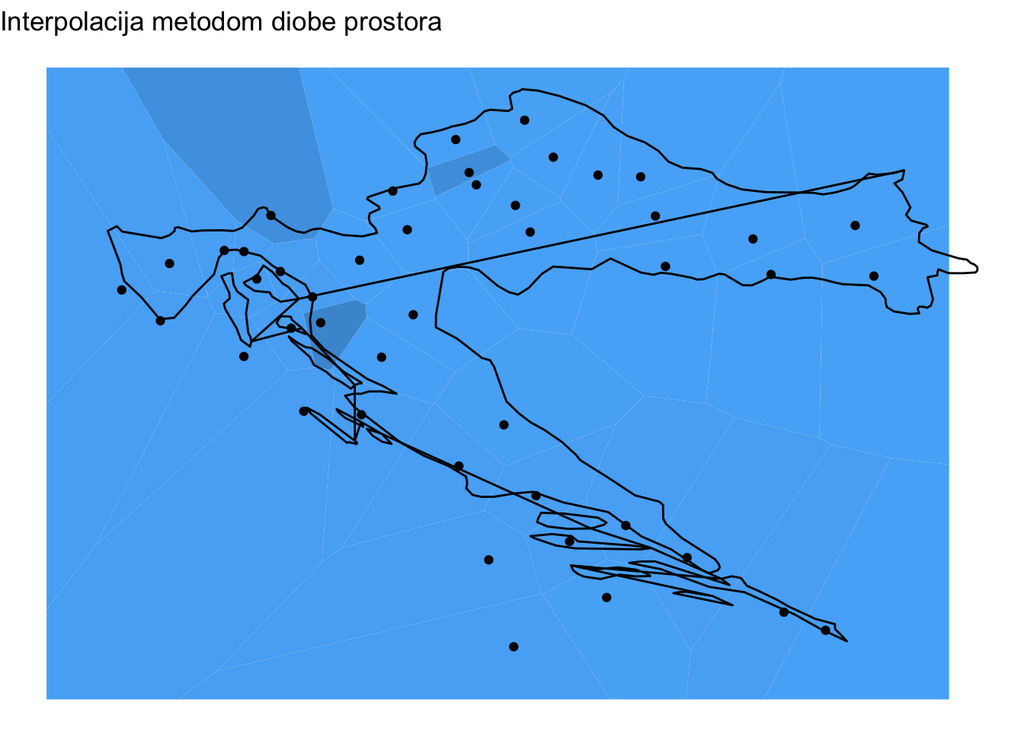

```r
plot(finalPlot)
```

### Zaključak

Metoda interpolacije najbližih susjeda i metoda diobe prostora(Voronoi) su u suštini slične metode interpolacije. Obadvije metode za točke predikcije traže najbližu točku opažanja te dodjeljuju vrijednost najbliže točke opažanja. Programsko okruženje R se pokazalo kao jedan od mogućih alata za analitičku obradu podataka. No međutim, zbog loše dokumentacije knjižnica funkcija korištenje R programskog jezika predstavlja svojevrsni izazov.